# readTimCottier

2025-12-09

Can’t test against a constant in quid .

Easiest thing:

Compare unconstrained model to the model that each individual has a positive true score.

But to do that, still can’t use their library because it’s set up for two conditions.

The way Haaf and Rouder define it, the hypothesis is about the sample not the population. Not important for the direction we are going in.

The standardized effect size of the FLE , the average relative to residuals (measurement error or between-session variance). In the model will go a point estimate and a prior on the between-session variance distribution, assuming some could be negative (the unconstrained model).

```r
#install.packages("R.matlab")
#install.packages("quid")
library(R.matlab)
library(quid) ##Haaf Rouder qualitative difference package
library(tidyverse)
```

## Load our data

Give data better column names

Each has three columns: participant number, Column 2 is pixels column 3 is dva

Need to re-arrange the data so that session number is a column (make session long rather than wide)

ID is the participant ID; and cond, a factor with two levels indicating the condition (1 = congruent, 2 = incongruent)

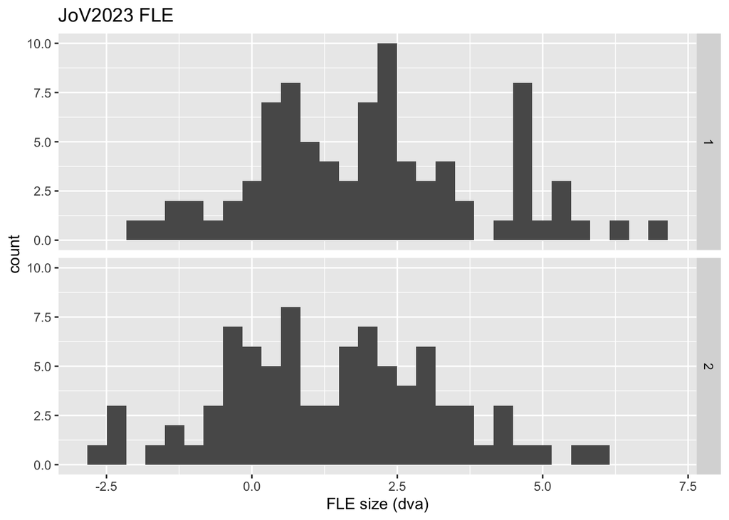

## Reproduce scatterplot of s1 and s2

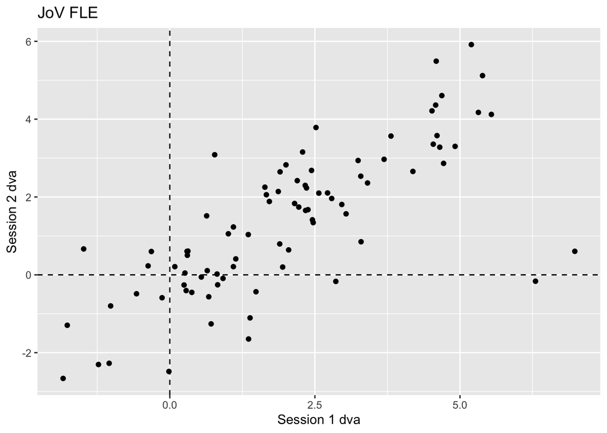

```r
wide <- myOverallJoV %>%
  select(ID, dva, session) %>%
  pivot_wider(
    names_from = session,
    values_from = dva,
    names_prefix = "dva_"
  )

s1s2scatter<- ggplot(wide, aes(x = dva_1, y = dva_2)) +
  geom_point() +
  labs(
    x = "Session 1 dva",
    y = "Session 2 dva"
  ) +
  geom_vline(xintercept = 0, linetype = "dashed") +
  geom_hline(yintercept = 0, linetype = "dashed") +
  ggtitle("JoV FLE")
  #geom_abline() #reveals reduction from S1 to S2, consitent with practice triggering faster sampling of position


show(s1s2scatter)
```

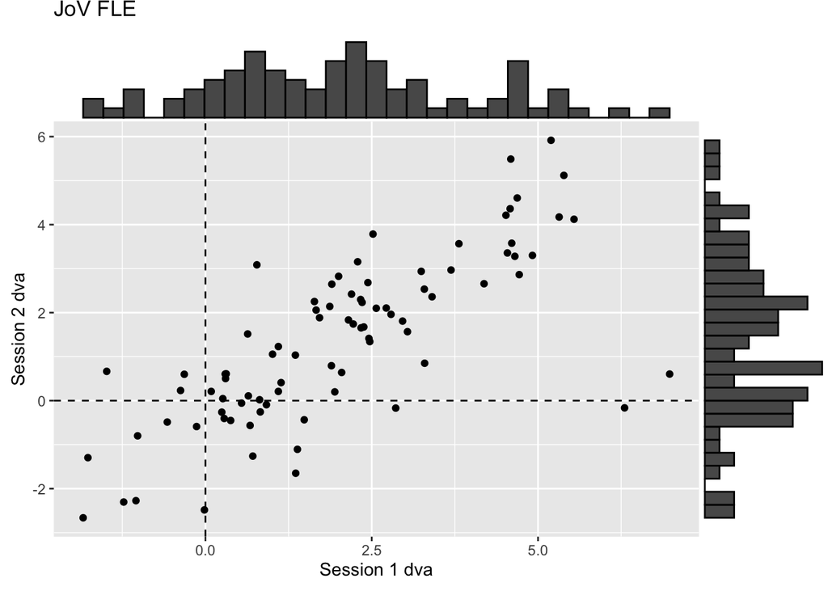

```r
#install.packages('ggExtra')
library(ggExtra)

ggMarginal(s1s2scatter, type = "histogram")
```

#European Journal of Neuroscience 2025 paper

This pic includes participants that were also in JoV

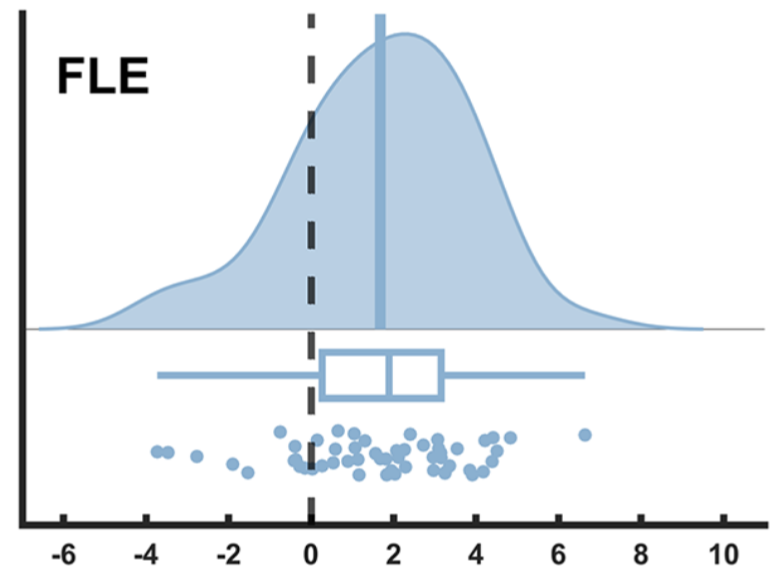

```r
knitr::include_graphics("EJN2025_FLE_histogram.png")
```

Load EJN-specific participants, from https://osf.io/jxeu3

Link: https://osf.io/jxeu3/files/2x8pg File is: single_sess.csv

```r
#Participants who weren't also in JOV dataset
EJNonlyParticipants <- read_csv("Single_Sess(EJN2025).csv")
na_count <- sum(is.na(EJNonlyParticipants$FLE))
cat("Number of NAs in FLE:", na_count, "\n")
```

```
## Number of NAs in FLE: 6
```

```r
print("Tim: I think the nans are because their staircases did not converge and we excluded them")
```

```
## [1] "Tim: I think the nans are because their staircases did not converge and we excluded them"
```

```r
print("But i think this is where reanalysing the data later on, we could be more liberal maybe? Alex: I think we should do both")
```

```
## [1] "But i think this is where reanalysing the data later on, we could be more liberal maybe? Alex: I think we should do both"
```

```r
EJNonlyParticipants <- EJNonlyParticipants %>%
  drop_na(FLE)
```

To decide on a prior for true score population mean and inter-individual variance, Plot histogram of EJN only Ss

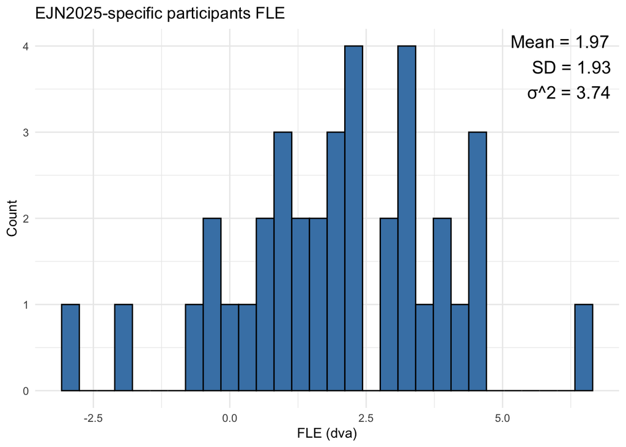

```r
mean_val <- mean(EJNonlyParticipants$FLE)
sd_val <- sd(EJNonlyParticipants$FLE)

# Create histogram with text
ggplot(EJNonlyParticipants, aes(x = FLE)) +
  geom_histogram(bins = 30, fill = "steelblue", color = "black") +
  annotate("text", x = Inf, y = Inf,
           label = paste0("Mean = ", round(mean_val, 2), "\n",
                         "SD = ", round(sd_val, 2), "\n",
                         "σ^2 = ", round(sd_val*sd_val, 2)),
           hjust = 1.1, vjust = 1.1, size = 5) +
  labs(title = "EJN2025-specific participants FLE", x = "FLE (dva)", y = "Count") +
  theme_minimal()
```

## FGE

FGE<- readMat(“FG_Values(JOV).mat”) # https://osf.io/s4aqg/files/8kvsm

## To-Do:

Once we get the staircase-level data (I think there are multiple staircases per session), we can have multiple observations per session and run the whole test on the second session . Because we noticed that the illusion tends to be smaller in the second session, presumably because of practice with the task helping the temporal binding/sampling. But there isn’t a big reason to do that.

- Get the data for the other illusions and run the model on each of them
- Analyse the effect of session and test the hypotehsis that the FLE is smaller for certain illusions with more temporal component such as FLE
- Sanity-check by doing my biasing dummy-coding hack to get the quid library to work with this one-condition data